# A2: Differential Gene expression and Preliminary ORA

Daniel Heydari

3/15/2022

# Introduction

In this assignment, the task was to use the normalized expression data from A1 and rank the genes via differential expression. The genetic data being used was downloaded from GEO with id GSE158890 [(Link)](https://www.ncbi.nlm.nih.gov/geo/query/acc.cgi?acc=GSE158890). The RNAseq data was collected by Koukoulas et al., as part of a study looking to better understand the role of Hypoxia inducible factor-1 (HIF-1) and Nucleophosmin 1 (NPM1) on gene expression under hypoxia.

## Required Packages

```r
#install.packages('knitr', dependencies = TRUE)

library(knitr)
library(devtools)
library(limma)
library(edgeR)
library(dplyr)
library(magrittr)
library(kableExtra)
library(circlize)
library(ComplexHeatmap)
library(Biobase)

if (!require("BiocManager", quietly = TRUE))
    install.packages("BiocManager")

#BiocManager::install("ComplexHeatmap")

#install.packages("circlize")
```

## Read in the data

```r
normalized_count_data <- read.table(file=file.path(getwd(),"data",
                "GSE158890_normalized_counts.txt"),
                                    header = TRUE,sep = "\t",
                                    stringsAsFactors = FALSE,
                                    check.names=FALSE)
```

# Generate Heatmap

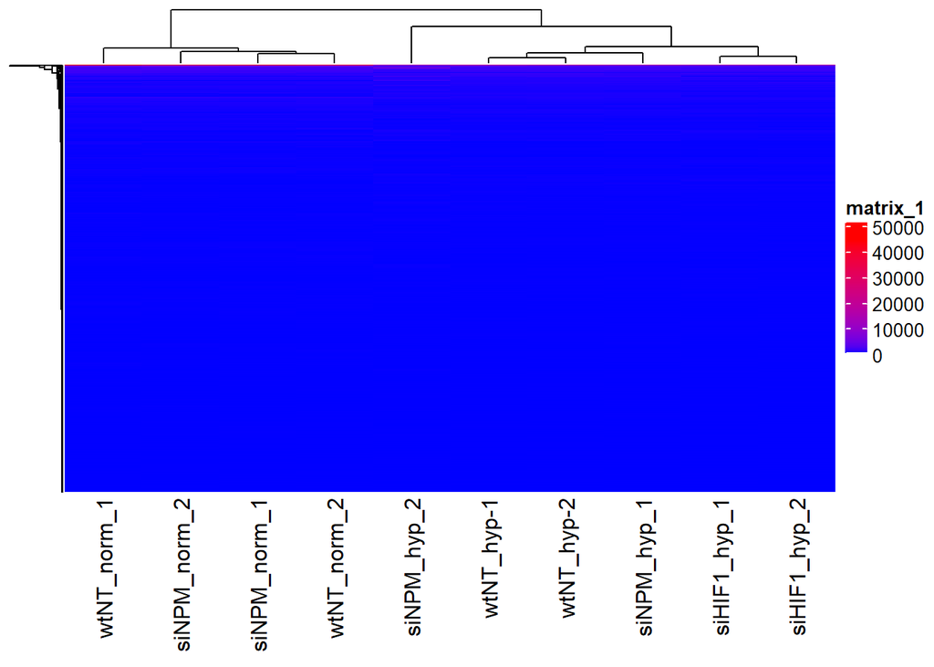

```r
library(ComplexHeatmap)
library(circlize)

heatmap_matrix <- normalized_count_data
rownames(heatmap_matrix) <- rownames(normalized_count_data)
colnames(heatmap_matrix) <- colnames(normalized_count_data[,
                        1:ncol(normalized_count_data)])

if(min(heatmap_matrix) == 0){
    heatmap_col = colorRamp2(c( 0, max(heatmap_matrix)),
                             c( "white", "red"))
  } else {
    heatmap_col = colorRamp2(c(min(heatmap_matrix), 0,
          max(heatmap_matrix)), c("blue", "white", "red"))
  }
current_heatmap <- Heatmap(as.matrix(heatmap_matrix),
      show_row_dend = TRUE,show_column_dend = TRUE,
      col=heatmap_col,show_column_names = TRUE,
      show_row_names = FALSE,show_heatmap_legend = TRUE)

plot(current_heatmap)
```

## Row Normalized Heatmap

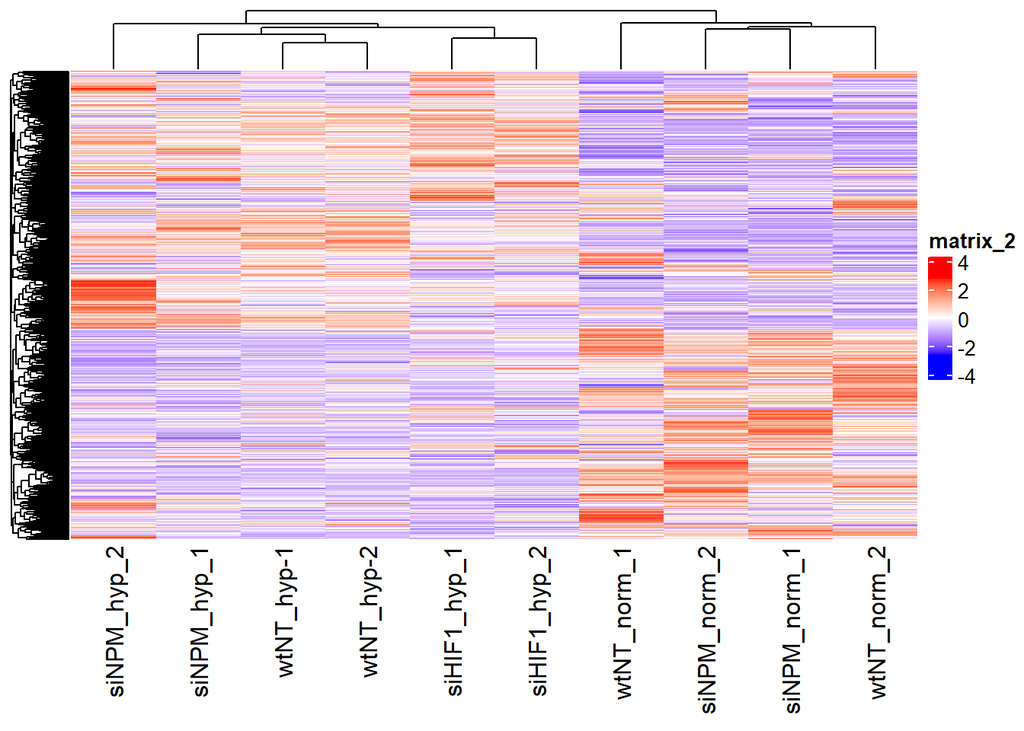

```r
heatmap_matrix <- t(scale(t(heatmap_matrix)))
  if(min(heatmap_matrix) == 0){
    heatmap_col = colorRamp2(c( 0, max(heatmap_matrix)),
                      c( "white", "red"))
  } else {
    heatmap_col = colorRamp2(c(min(heatmap_matrix), 0,
        max(heatmap_matrix)), c("blue", "white", "red"))
  }
current_heatmap <- Heatmap(as.matrix(heatmap_matrix),
      show_row_dend = TRUE,show_column_dend = TRUE,
      col=heatmap_col,show_column_names = TRUE,
      show_row_names = FALSE,show_heatmap_legend = TRUE)

plot(current_heatmap)
```

# Separate Samples The paper finds that extracellular signal‐regulated kinases1/2 (ERK1/2) promote HIF/NPM1 processess, so this was used as the GoI. ERK1 -> HGNC: MAPK3 -> EnsemblID: ENSG00000102882

```r
siNPM_hyp_samples <- grep(colnames(normalized_count_data),
                          pattern="siNPM_hyp")

wtNT_hyp_samples <- grep(colnames(normalized_count_data),
                          pattern="wtNT_hyp")

wtNT_norm_samples <- grep(colnames(normalized_count_data),
                          pattern="wtNT_norm")

siNPM_norm_samples <- grep(colnames(normalized_count_data),
                          pattern="siNPM_norm")

siHIF1_hyp_samples <- grep(colnames(normalized_count_data),
                          pattern="siHIF1_hyp")



gene_of_interest <- which(rownames(normalized_count_data) == "ENSG00000102882")

MAPK3_siNPM_hyp_samples <-  t(normalized_count_data  [gene_of_interest, siNPM_hyp_samples])

colnames(MAPK3_siNPM_hyp_samples) <-   c("MAPK3 siNPM_hyp Samples")

MAPK3_siNPM_hyp_samples
```

```
##             MAPK3 siNPM_hyp Samples
## siNPM_hyp_1                8.505212
## siNPM_hyp_2                8.621469
```

```r
MAPK3_siHIF1_hyp_samples <-  t(normalized_count_data  [gene_of_interest, siHIF1_hyp_samples])

colnames(MAPK3_siHIF1_hyp_samples) <-   c("MAPK3 siHIF1_hyp_samples")

MAPK3_siHIF1_hyp_samples
```

```
##              MAPK3 siHIF1_hyp_samples
## siHIF1_hyp_1                 14.19944
## siHIF1_hyp_2                 11.52089
```

```r
MAPK3_wtNT_hyp_samples <-  t(normalized_count_data  [gene_of_interest, wtNT_hyp_samples])

colnames(MAPK3_wtNT_hyp_samples) <-   c("MAPK3 wtNT_hyp Samples")

MAPK3_wtNT_hyp_samples
```

```
##            MAPK3 wtNT_hyp Samples
## wtNT_hyp-1              10.473417
## wtNT_hyp-2               9.457734
```

```r
MAPK3_wtNT_norm_samples <-  t(normalized_count_data  [gene_of_interest, wtNT_norm_samples])

colnames(MAPK3_wtNT_norm_samples) <-   c("MAPK3 wtNT_norm Samples")

MAPK3_wtNT_norm_samples
```

```
##             MAPK3 wtNT_norm Samples
## wtNT_norm_1               17.511359
## wtNT_norm_2                5.729812
```

```r
MAPK3_siNPM_norm_samples <-  t(normalized_count_data  [gene_of_interest, siNPM_norm_samples])

colnames(MAPK3_siNPM_norm_samples) <-   c("MAPK3 siNPM_norm Samples")

MAPK3_siNPM_norm_samples
```

```
##              MAPK3 siNPM_norm Samples
## siNPM_norm_1                12.380673
## siNPM_norm_2                 1.931086
```

# Welch Two-Sample t-test (Between siNPM_hyp and wtNT_hyp)

I chose siNPM_hyp and wtNT_hyp, because I wanted to see if there would be differences in expression of MAPK3 in hypoxia conditions, between the wildtype, and the NPM1 silenced.

```r
t.test(x=t(MAPK3_siNPM_hyp_samples),y=t(MAPK3_wtNT_hyp_samples))
```

```
##
##  Welch Two Sample t-test
##
## data:  t(MAPK3_siNPM_hyp_samples) and t(MAPK3_wtNT_hyp_samples)
## t = -2.7433, df = 1.0262, p-value = 0.2174
## alternative hypothesis: true difference in means is not equal to 0
## 95 percent confidence interval:
##  -7.518085  4.713615
## sample estimates:
## mean of x mean of y
##  8.563340  9.965575
```

# Limma Variable Controls

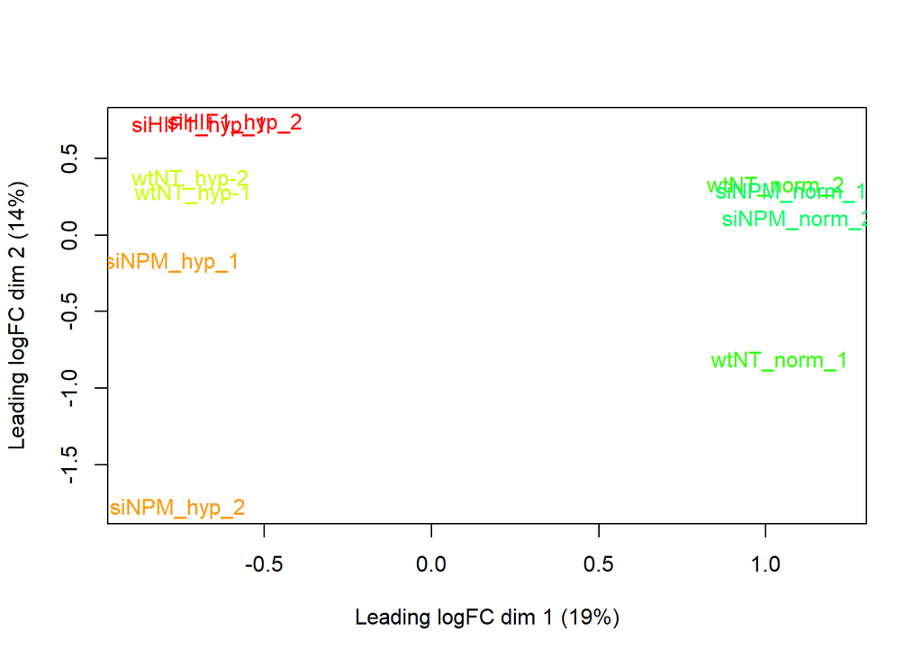

```r
pat_colors <- rainbow(10)
pat_colors <- unlist(lapply(pat_colors,FUN=function(x){rep(x,2)}))

limma::plotMDS(heatmap_matrix, col = pat_colors )
```

# Model and Create Data Matrix

```r
# Sample design from A1

# Hard fix because wtNT_hyp 1 and 2 are named using dash ('-'), instead of underscore ('_')

colnames(normalized_count_data) <- c('siHIF1_hyp_1', 'siHIF1_hyp_2', 'siNPM_hyp_1', 'siNPM_hyp_2',  'wtNT_hyp_1', 'wtNT_hyp_2', 'wtNT_norm_1','wtNT_norm_2', 'siNPM_norm_1', 'siNPM_norm_2')

samples <- data.frame(lapply(colnames(normalized_count_data),
                             FUN=function(x){unlist(strsplit(x,
                                                             split = "\\_"))[c(1,2,3)]}))
colnames(samples) <- colnames(normalized_count_data)
rownames(samples) <- c("type", "condition","patients")
samples <- data.frame(t(samples))

#Generating simple model design

model_design <- model.matrix(~ samples$type)

expressionMatrix <- as.matrix(normalized_count_data)
rownames(expressionMatrix) <- rownames(normalized_count_data)
colnames(expressionMatrix) <- colnames(normalized_count_data)
minimalSet <- ExpressionSet(assayData=expressionMatrix)

fit <- lmFit(minimalSet, model_design)


# Applying Empirical Bayes to compute differential expression

fit2 <- eBayes(fit,trend=TRUE)


topfit <- topTable(fit2,
 coef=ncol(model_design),
 adjust.method = "BH",
 number = nrow(expressionMatrix))

#merge topfit table with Ensembl IDs

output_hits <- merge(rownames(normalized_count_data),
 topfit,
 by.y=0,by.x=1,
 all.y=TRUE)

#sort by pvalue
output_hits <- output_hits[order(output_hits$P.Value),]


kable(output_hits[1:10,],type="html",row.names = FALSE)
```

| x | logFC | AveExpr | t | P.Value | adj.P.Val | B |
| --- | --- | --- | --- | --- | --- | --- |
| ENSG00000089351 | 129.182531 | 163.214841 | 6.558520 | 0.0000824 | 0.3399511 | -4.123853 |
| ENSG00000132432 | 615.711387 | 1134.646413 | 6.143211 | 0.0001374 | 0.3399511 | -4.137673 |
| ENSG00000198931 | -112.347159 | 106.321896 | -5.935363 | 0.0001790 | 0.3399511 | -4.145380 |
| ENSG00000136810 | 184.593103 | 197.161259 | 5.933728 | 0.0001794 | 0.3399511 | -4.145443 |
| ENSG00000138061 | -100.918170 | 61.934745 | -5.924198 | 0.0001816 | 0.3399511 | -4.145811 |
| ENSG00000157657 | -13.080349 | 9.535113 | -5.845555 | 0.0002010 | 0.3399511 | -4.148891 |
| ENSG00000252531 | 201.401884 | 668.918628 | 5.533608 | 0.0003034 | 0.4318519 | -4.161999 |
| ENSG00000153721 | -6.413836 | 4.483503 | -5.448009 | 0.0003405 | 0.4318519 | -4.165862 |
| ENSG00000102981 | -12.612801 | 8.010445 | -4.950051 | 0.0006799 | 0.5210460 | -4.190904 |
| ENSG00000072506 | -351.500310 | 594.281544 | -4.914291 | 0.0007155 | 0.5210460 | -4.192885 |

# p-value and Multiple hypothesis testing Analysis

## How many gene pass the threshold p-value < 0.05?

```r
length(which(output_hits$P.Value < 0.05))
```

```
## [1] 697
```

## How many genes pass correction

```r
length(which(output_hits$adj.P.Val < 0.05))
```

```
## [1] 0
```

# Improving the Model

```r
model_design_pat <- model.matrix(
 ~ samples$type + samples$condition)

kable(model_design_pat, type="html")
```

[output not shown]

```r
# Fit our data to the model created above
fit_pat <- lmFit(minimalSet, model_design_pat)
```

# Analyzing the Improved Model

## Empirical Bayes to compute diff. expression

```r
fit2_pat <- eBayes(fit_pat,trend=TRUE)

topfit_pat <- topTable(fit2_pat,
 coef=ncol(model_design_pat),
 adjust.method = "BH",
 number = nrow(expressionMatrix))

# merge topfit table with Ensembl IDs
output_hits_pat <- merge(normalized_count_data[,1:1],
 topfit_pat,by.y=0,by.x=1,
 all.y=TRUE)

# sort by pvalue
output_hits_pat <- output_hits_pat[order(output_hits_pat$P.Value),]

# Display top 10

kable(output_hits_pat[1:10,], type="html",row.names = FALSE)
```

| x | logFC | AveExpr | t | P.Value | adj.P.Val | B |
| --- | --- | --- | --- | --- | --- | --- |
| ENSG00000106028 | 466.7578 | 412.9311 | 27.14700 | 0 | 3.0e-06 | -3.190084 |
| ENSG00000103257 | 700.8802 | 716.2248 | 26.46487 | 0 | 3.0e-06 | -3.191239 |
| ENSG00000170516 | 437.8469 | 246.1802 | 26.04837 | 0 | 3.0e-06 | -3.191988 |
| ENSG00000117289 | -207.0044 | 158.8760 | -22.62041 | 0 | 6.6e-06 | -3.199770 |
| ENSG00000096384 | 556.3971 | 539.3719 | 22.46623 | 0 | 6.6e-06 | -3.200204 |
| ENSG00000134333 | -686.7576 | 666.0094 | -21.63274 | 0 | 6.9e-06 | -3.202706 |
| ENSG00000112096 | -289.1747 | 187.5145 | -21.25291 | 0 | 6.9e-06 | -3.203942 |
| ENSG00000144381 | 241.8304 | 231.9130 | 21.20090 | 0 | 6.9e-06 | -3.204116 |
| ENSG00000185022 | -138.1184 | 81.0627 | -20.50351 | 0 | 7.7e-06 | -3.206578 |
| ENSG00000197555 | 199.6145 | 218.0542 | 20.41361 | 0 | 7.7e-06 | -3.206913 |

## How many gene pass the threshold p-value < 0.05?

```r
length(which(output_hits_pat$P.Value < 0.05))
```

```
## [1] 4354
```

## How many genes pass correction

```r
length(which(output_hits_pat$adj.P.Val < 0.05))
```

```
## [1] 3196
```

# Comparing the Simple and Gene Type Model

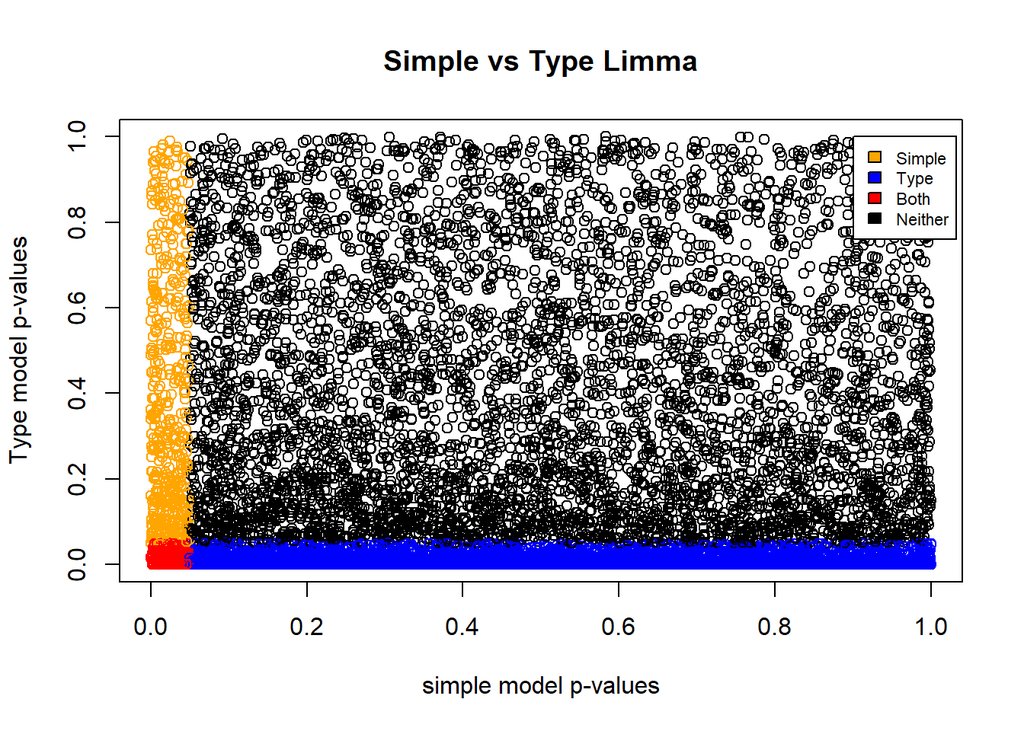

```r
simple_model_pvalues <- data.frame(ensembl_id = output_hits$x, simple_pvalue=output_hits$P.Value)

type_model_pvalues <- data.frame(ensembl_id = output_hits_pat$x, type_pvalue = output_hits_pat$P.Value)

two_models_pvalues <- merge(simple_model_pvalues, type_model_pvalues,by.x=1,by.y=1)

two_models_pvalues$colour <- "black"

two_models_pvalues$colour[ two_models_pvalues$simple_pvalue<0.05] <- "orange"

two_models_pvalues$colour[ two_models_pvalues$type_pvalue <0.05] <- "blue"

two_models_pvalues$colour[ two_models_pvalues$simple_pvalue<0.05 & two_models_pvalues$type_pvalue<0.05] <- "red"


plot(two_models_pvalues$simple_pvalue, two_models_pvalues$type_pvalue, col = two_models_pvalues$colour, xlab = "simple model p-values", ylab ="Type model p-values", main="Simple vs Type Limma")
legend(0.9, 1, legend=c("Simple", "Type", "Both", "Neither"), cex = 0.7 ,  fill=c("orange", "blue", 'red', 'black'))
```

Figure: Blue represents genes that were found to be significant in the Type-based model, Orange those significant in Simple model, and Red is those significant in both

# Comparing the Simple and Gene Type Model looking for GoI: MAPK3

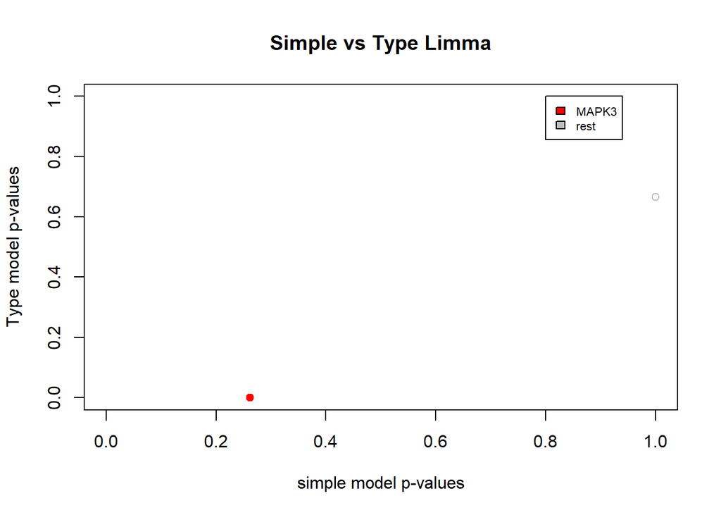

```r
ensembl_of_interest <- rownames(normalized_count_data)[ which("ENSG00000102882" %in% rownames(normalized_count_data))]

two_models_pvalues$colour <- "grey"

two_models_pvalues$colour[two_models_pvalues$ensembl_id== ensembl_of_interest] <- "red"

plot(two_models_pvalues$simple_pvalue,
 two_models_pvalues$patient_pvalue,
 col = two_models_pvalues$colour,
 xlim=c(0,1), ylim=c(0,1),
 xlab = "simple model p-values",
 ylab ="Type model p-values",
 main="Simple vs Type Limma")
points(two_models_pvalues[which(
 two_models_pvalues$ensembl_id == ensembl_of_interest),2:3],
 pch=20, col="red", cex=1.5)
legend(0.8,1,legend=c("MAPK3","rest"),
 fill=c("red","grey"),cex = 0.7)
```

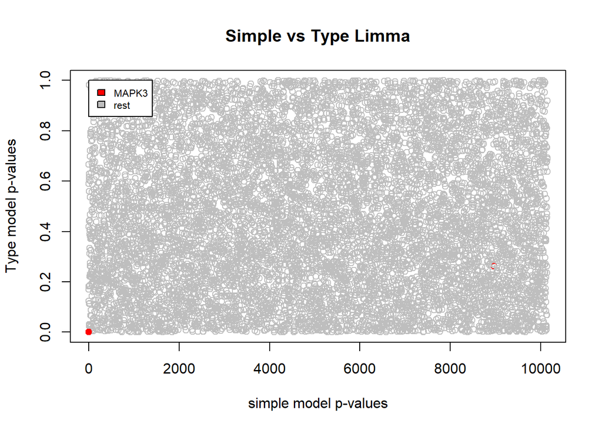

```r
plot(two_models_pvalues$simple_pvalue,
 two_models_pvalues$patient_pvalue,
 col = two_models_pvalues$colour,
 xlab = "simple model p-values",
 ylab ="Type model p-values",
 main="Simple vs Type Limma")
points(two_models_pvalues[which(
 two_models_pvalues$ensembl_id == ensembl_of_interest),2:3],
 pch=20, col="red", cex=1.5)
legend(0.8,1,legend=c("MAPK3","rest"),
 fill=c("red","grey"),cex = 0.7)
```

# Heatmap Using Limma

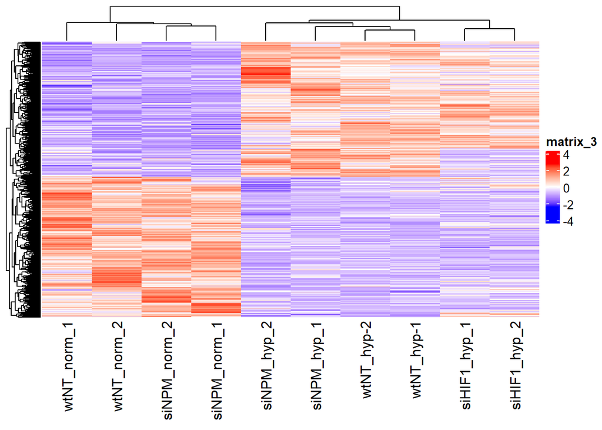

```r
top_hits <- output_hits_pat$x[output_hits_pat$P.Value<0.05]

heatmap_matrix_tophits <- t( scale(t(heatmap_matrix[ which(rownames(heatmap_matrix) %in% top_hits),])))

if(min(heatmap_matrix_tophits) == 0){
 heatmap_col = colorRamp2(c( 0, max(heatmap_matrix_tophits)),
 c( "white", "red"))
 } else {

 heatmap_col = colorRamp2(c(min(heatmap_matrix_tophits), 0, max(heatmap_matrix_tophits)), c("blue", "white", "red"))
 }

current_heatmap <- Heatmap(as.matrix(heatmap_matrix_tophits),
 cluster_rows = TRUE,
 cluster_columns = TRUE,
 show_row_dend = TRUE,
 show_column_dend = TRUE,
 col=heatmap_col,
 show_column_names = TRUE,
 show_row_names = FALSE,
 show_heatmap_legend = TRUE,
 )

plot(current_heatmap)
```

# Heatmap with Model and Limma

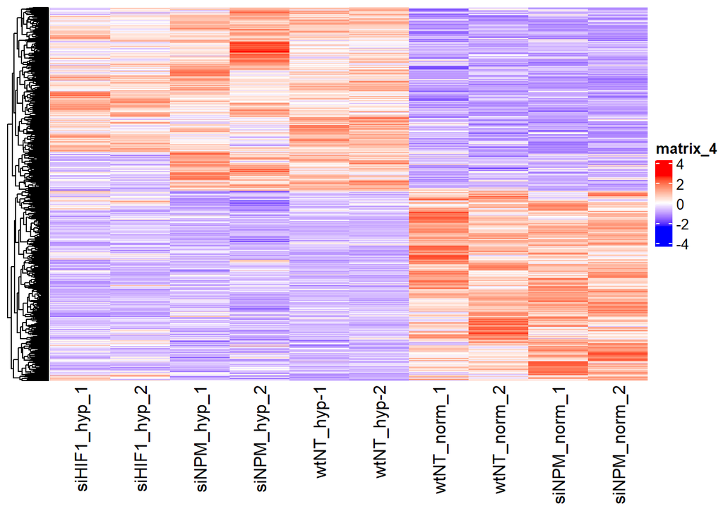

```r
heatmap_matrix_tophits<- heatmap_matrix_tophits[,
     c(grep(colnames(heatmap_matrix_tophits),
     pattern = "siHIF1_hyp"),
     grep(colnames(heatmap_matrix_tophits),
     pattern = "siNPM_hyp"),
     grep(colnames(heatmap_matrix_tophits),
     pattern = "wtNT_hyp"),
     grep(colnames(heatmap_matrix_tophits),
     pattern = "wtNT_norm"),
     grep(colnames(heatmap_matrix_tophits),
     pattern = "siNPM_norm"))]


if(min(heatmap_matrix_tophits) == 0){
 heatmap_col = colorRamp2(c( 0, max(heatmap_matrix_tophits)),
 c( "white", "red"))
 } else {
 heatmap_col = colorRamp2(c(min(heatmap_matrix_tophits), 0,
 max(heatmap_matrix_tophits)),
 c("blue", "white", "red"))
 }

current_heatmap <- Heatmap(as.matrix(heatmap_matrix_tophits),
 cluster_rows = TRUE,
 cluster_columns = FALSE,
 show_row_dend = TRUE,
 show_column_dend = TRUE,
 col=heatmap_col,
 show_column_names = TRUE,
 show_row_names = FALSE,
 show_heatmap_legend = TRUE,
 )

plot(current_heatmap)
```

# Heatmap of Top Hits with Limma (p < 0.01)

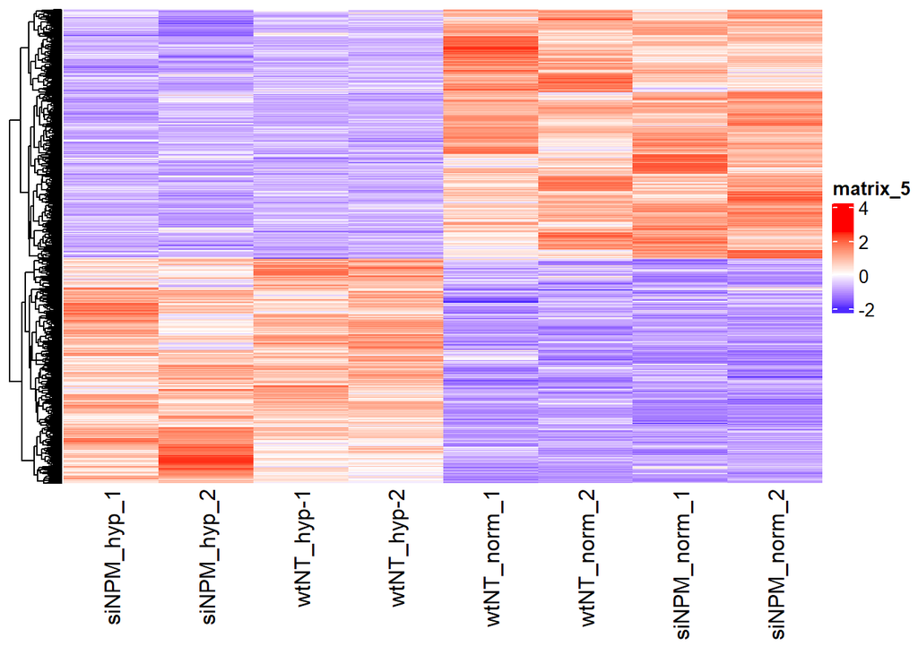

```r
top_hits <- output_hits_pat$x[
 output_hits_pat$P.Value<0.01]
heatmap_matrix_tophits <- t(
 scale(t(heatmap_matrix[which(rownames(heatmap_matrix)
 %in% top_hits),])))
heatmap_matrix_tophits<- heatmap_matrix_tophits[,
     c(grep(colnames(heatmap_matrix_tophits),
     pattern = "siNPM_hyp"),
     grep(colnames(heatmap_matrix_tophits),
     pattern = "wtNT_hyp"),
     grep(colnames(heatmap_matrix_tophits),
     pattern = "wtNT_norm"),
     grep(colnames(heatmap_matrix_tophits),
     pattern = "siNPM_norm"))]
if(min(heatmap_matrix_tophits) == 0){
 heatmap_col = colorRamp2(c( 0, max(heatmap_matrix_tophits)),
 c( "white", "red"))
 } else {
 heatmap_col = colorRamp2(c(min(heatmap_matrix_tophits), 0,
 max(heatmap_matrix_tophits)),
 c("blue", "white", "red"))
 }
current_heatmap <- Heatmap(as.matrix(heatmap_matrix_tophits),
 cluster_rows = TRUE, show_row_dend = TRUE,
 cluster_columns = FALSE,show_column_dend = FALSE,
 col=heatmap_col,show_column_names = TRUE,
 show_row_names = FALSE,show_heatmap_legend = TRUE)

plot(current_heatmap)
```

# EdgeR: Quasi Liklihood Test

I chose Quasi Liklihood test as it was Prof. Isserlin’s recommendation in lecture; the dataset has a relatively large number of samples and factors causing variability.

```r
# Setting up edgeR matrix

cpms = cpm(normalized_count_data)
rownames(cpms) <- normalized_count_data[,1]
keep = rowSums(cpms >1) >=10
filtered_data <- normalized_count_data[keep,]
filtered_data_matrix <- as.matrix(filtered_data)

d = DGEList(counts=filtered_data_matrix, group=samples$type)

# Estimating Dispersion

d <- estimateDisp(d, model_design_pat)
# Fit the model

fit <- glmQLFit(d, model_design_pat)

kable(model_design_pat, type="html") %>% row_spec(0, angle = -45)
```

[output not shown]

Calculate diff. exp. using Quasi Liklihood method

```r
qlf.siNPM_hyp_vs_other <- glmQLFTest(fit, coef='samples$typesiNPM')
kable(topTags(qlf.siNPM_hyp_vs_other), type="html",row.names = FALSE)
```

| logFC | logCPM | F | PValue | FDR |
| --- | --- | --- | --- | --- |
| 3.779755 | 9.291200 | 166.13278 | 0e+00 | 0.0000007 |
| 3.994325 | 6.757774 | 115.90135 | 0e+00 | 0.0000076 |
| 2.850587 | 7.172749 | 103.70625 | 0e+00 | 0.0000126 |
| 2.898418 | 7.143851 | 88.96269 | 0e+00 | 0.0000324 |
| 3.061674 | 6.390234 | 81.08305 | 0e+00 | 0.0000538 |
| 4.187665 | 5.067348 | 77.45074 | 0e+00 | 0.0000640 |
| 3.590430 | 5.543861 | 71.16219 | 1e-07 | 0.0001052 |
| 2.375107 | 6.127525 | 68.64034 | 1e-07 | 0.0001211 |
| 2.277699 | 12.882290 | 58.48140 | 3e-07 | 0.0003239 |
| 2.231023 | 8.514523 | 58.35660 | 3e-07 | 0.0003239 |

| x |
| --- |
| BH |

| x |
| --- |
| samples$typesiNPM |

| x |
| --- |
| glm |

```r
qlf_output_hits <- topTags(qlf.siNPM_hyp_vs_other,sort.by = "PValue",
 n = nrow(normalized_count_data))

# How many gene pass the threshold p-value < 0.05?

length(which(qlf_output_hits$table$PValue < 0.05))
```

```
## [1] 1505
```

```r
# How many genes pass correction?

length(which(qlf_output_hits$table$FDR < 0.05))
```

```
## [1] 139
```

# Comparing Limma & Quasi Liklihood Models

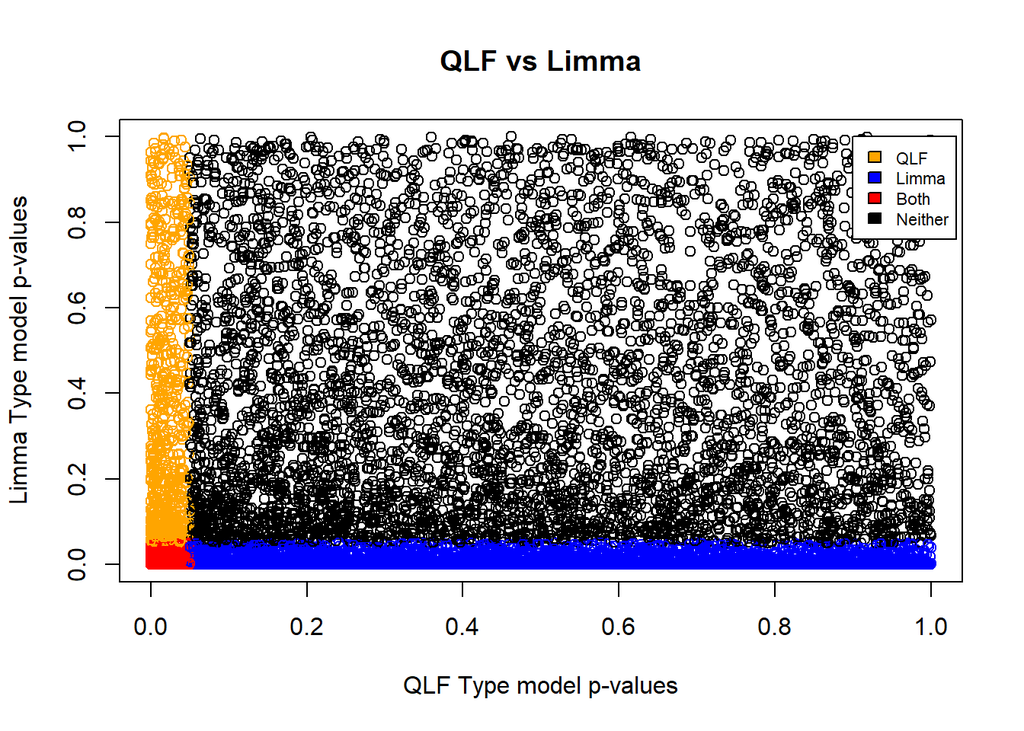

```r
qlf_pat_model_pvalues <- data.frame(
 ensembl_id = rownames(qlf_output_hits$table),
 qlf_patient_pvalue=qlf_output_hits$table$PValue)
limma_pat_model_pvalues <- data.frame(
 ensembl_id = output_hits_pat$x,
 limma_patient_pvalue = output_hits_pat$P.Value)
two_models_pvalues <- merge(qlf_pat_model_pvalues,
 limma_pat_model_pvalues,
 by.x=1,by.y=1)
two_models_pvalues$colour <- "black"
two_models_pvalues$colour[two_models_pvalues$qlf_patient_pvalue
 <0.05] <- "orange"
two_models_pvalues$colour[two_models_pvalues$limma_patient_pvalue
 <0.05] <- "blue"
two_models_pvalues$colour[two_models_pvalues$qlf_patient_pvalue
 <0.05 &
two_models_pvalues$limma_patient_pvalue<0.05] <- "red"
plot(two_models_pvalues$qlf_patient_pvalue,
 two_models_pvalues$limma_patient_pvalue,
 col = two_models_pvalues$colour,
 xlab = "QLF Type model p-values",
 ylab ="Limma Type model p-values",
 main="QLF vs Limma")

legend(0.9, 1, legend=c("QLF", "Limma", "Both", "Neither"), cex = 0.7 ,  fill=c("orange", "blue", 'red', 'black'))
```

```r
# Orange represents genes significantly detected using Quasi-Liklihood, Blue those significant with Limma, Red for those significant in both, and Black for those significant in neither.
```

# Comparing Limma and QLF looking for GoI: MAPK3

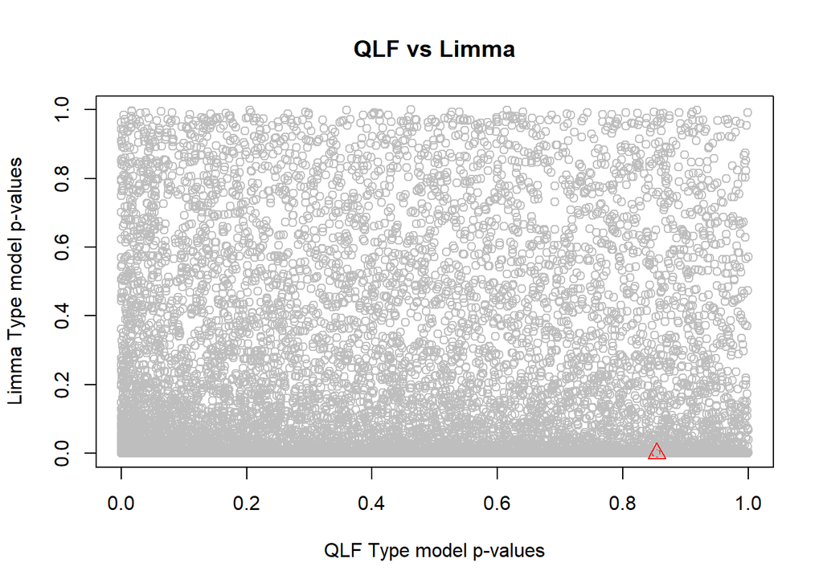

```r
ensembl_of_interest <- rownames(normalized_count_data)[ which("ENSG00000102882" %in% rownames(normalized_count_data))]

two_models_pvalues$colour <- "grey"
two_models_pvalues$colour[two_models_pvalues$ensembl_id
 ==ensembl_of_interest] <- "red"
plot(two_models_pvalues$qlf_patient_pvalue,
 two_models_pvalues$limma_patient_pvalue,
 col = two_models_pvalues$colour,
 xlab = "QLF Type model p-values",
 ylab ="Limma Type model p-values",
 main="QLF vs Limma")
points(two_models_pvalues[
 two_models_pvalues$ensembl_id==ensembl_of_interest,2:3],
 pch=24, col="red", cex=1.5)
```

```r
# MAPK3 Gene was only found to be significantly expressed in the Limma model
```